# Tuto barplot - ggplot2

### Fix levels order

Sur les graphes on veut l’affichage des axes dans l’ordre suivant:

- “Jejunum” “Colon”
- “Jejunum_D21” “Jejunum_D35” “Colon_D21” “Colon_D35”
- “P0” “P1” “P2”

```r
levels(data$Segment)
## [1] "Colon"   "Jejunum"
data$Segment <- factor(data$Segment, levels= c("Jejunum", "Colon"))
levels(data$Segment)
## [1] "Jejunum" "Colon"
data$Segment_Age <- factor(data$Segment_Age, levels= c("Jejunum_D21","Jejunum_D35", "Colon_D21", "Colon_D35"))
levels(data$Segment_Age)
## [1] "Jejunum_D21" "Jejunum_D35" "Colon_D21"   "Colon_D35"
levels(data$Passage)
## [1] "P0" "P1" "P2"
```

### Rajoute les pourcentages pourles types d’organoides

```r
data |>
  mutate(percent_Sphe = (Spherical*100)/Total) |>
  mutate(percent_NonSphe = (NonSpherical*100)/Total) -> data
data
```

```
## # A tibble: 122 × 10
##    Porc  Age   Segment Passage Segment_Age Total Spherical NonSpherical
##    <fct> <fct> <fct>   <fct>   <fct>       <dbl>     <dbl>        <dbl>
##  1 5     D35   Jejunum P0      Jejunum_D35  8.60      6.60         1.99
##  2 6     D35   Jejunum P0      Jejunum_D35  9.26      5.24         4.03
##  3 7     D35   Jejunum P0      Jejunum_D35  9.26      6.49         2.78
##  4 8     D35   Jejunum P0      Jejunum_D35 11.8       8.36         3.4
##  5 9     D21   Jejunum P0      Jejunum_D21  8.52      4.57         3.95
##  6 10    D21   Jejunum P0      Jejunum_D21  6.29      3.48         2.81
##  7 11    D21   Jejunum P0      Jejunum_D21  4.06      2.42         1.64
##  8 12    D21   Jejunum P0      Jejunum_D21  6.06      3.95         2.11
##  9 13    D35   Jejunum P0      Jejunum_D35  8.44      5.00         3.44
## 10 15    D35   Jejunum P0      Jejunum_D35  7.31      4.10         3.20
## # … with 112 more rows, and 2 more variables: percent_Sphe <dbl>,
## #   percent_NonSphe <dbl>
```

### Tidy data: pivot_longer

```r
data |>
  pivot_longer(cols = where(is.numeric),
               names_to = "Organoids_type",
               values_to = "value") -> data_tidy
data_tidy
```

```
## # A tibble: 610 × 7
##    Porc  Age   Segment Passage Segment_Age Organoids_type  value
##    <fct> <fct> <fct>   <fct>   <fct>       <chr>           <dbl>
##  1 5     D35   Jejunum P0      Jejunum_D35 Total            8.60
##  2 5     D35   Jejunum P0      Jejunum_D35 Spherical        6.60
##  3 5     D35   Jejunum P0      Jejunum_D35 NonSpherical     1.99
##  4 5     D35   Jejunum P0      Jejunum_D35 percent_Sphe    76.8
##  5 5     D35   Jejunum P0      Jejunum_D35 percent_NonSphe 23.2
##  6 6     D35   Jejunum P0      Jejunum_D35 Total            9.26
##  7 6     D35   Jejunum P0      Jejunum_D35 Spherical        5.24
##  8 6     D35   Jejunum P0      Jejunum_D35 NonSpherical     4.03
##  9 6     D35   Jejunum P0      Jejunum_D35 percent_Sphe    56.5
## 10 6     D35   Jejunum P0      Jejunum_D35 percent_NonSphe 43.5
## # … with 600 more rows
```

### function SEM

```r
sem <- function(x)
{
    sd(x)/sqrt(length(x))
}
```

### Rajoute les stats aux données

**21 jours**

```r
data_tidy |>
  filter(Age == "D21") |>
  filter(Organoids_type %in% c("percent_NonSphe", "percent_Sphe")) |>
  group_by(Passage, Segment, Organoids_type) |>
  summarise(across(where(is.numeric), list(moy = mean,
                                           sd = sd,
                                           count = length,
                                           SEM = sem))) -> data_stat
data_stat
```

```
## # A tibble: 12 × 7
## # Groups:   Passage, Segment [6]
##    Passage Segment Organoids_type  value_moy value_sd value_count value_SEM
##    <fct>   <fct>   <chr>               <dbl>    <dbl>       <int>     <dbl>
##  1 P0      Jejunum percent_NonSphe      51.4     9.62          12      2.78
##  2 P0      Jejunum percent_Sphe         48.6     9.62          12      2.78
##  3 P0      Colon   percent_NonSphe      56.8     9.34          12      2.70
##  4 P0      Colon   percent_Sphe         43.2     9.33          12      2.69
##  5 P1      Jejunum percent_NonSphe      53.2    12.1           12      3.51
##  6 P1      Jejunum percent_Sphe         46.8    12.1           12      3.51
##  7 P1      Colon   percent_NonSphe      33.2    10.6           12      3.06
##  8 P1      Colon   percent_Sphe         66.8    10.6           12      3.06
##  9 P2      Jejunum percent_NonSphe      43.5     6.43          12      1.86
## 10 P2      Jejunum percent_Sphe         56.5     6.43          12      1.86
## 11 P2      Colon   percent_NonSphe      33.4     5.27          12      1.52
## 12 P2      Colon   percent_Sphe         66.6     5.27          12      1.52
```

## Barplot des pourcentage de segment par type d’organoide avec barre de significativité

### Barres de significativité

**Simple**

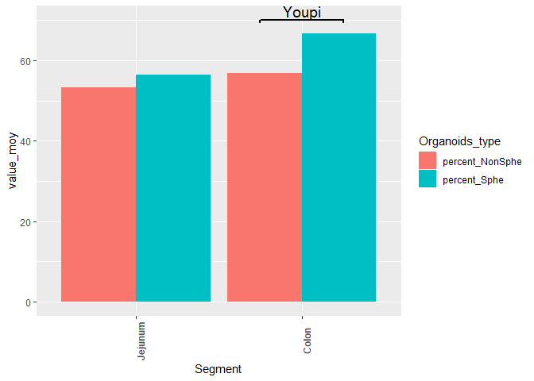

```r
data_stat |>
  ggplot(aes(x = Segment,
         y = value_moy,
         fill = Organoids_type)) +
  geom_col(position = "dodge") +
  theme(axis.text.x = element_text(angle = 90,
                                   face = "bold")) +
  geom_signif(annotation = "Youpi",
              y_position = max(data_stat$value_moy) + max(data_stat$value_moy)*0.05,
              xmin = c(1.75),
              xmax = c(2.25),
              tip_length = 0.02,
              size = 1,
              textsize = 5)
```

**Dans des facets**

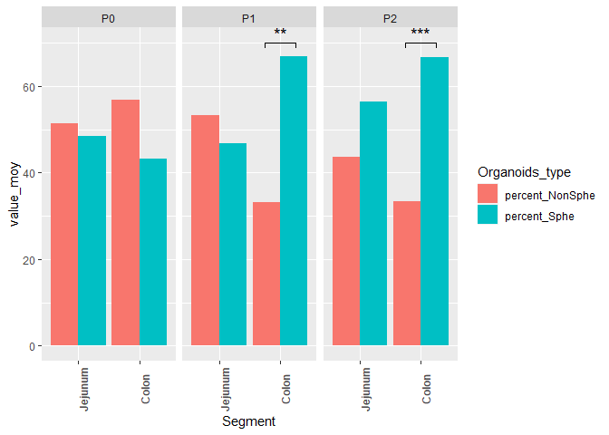

```r
data_stat |>
  ggplot(aes(x = Segment,
             y = value_moy)) +
  geom_col(aes(fill = Organoids_type),
           position = "dodge") +
  theme(axis.text.x = element_text(angle = 90,
                                   face = "bold")) +
  facet_grid(cols = vars(Passage)) +
  geom_signif(data = data.frame(Passage = c("P1", "P2")),
              aes(xmin = c(1.75, 1.75),
                  xmax = c(2.25, 2.25),
                  annotations = c("**", "***"),
                  y_position = c(70, 70)),
              textsize = 5,
              manual = TRUE)
```

### Figure imposée

**Graph à reproduire**

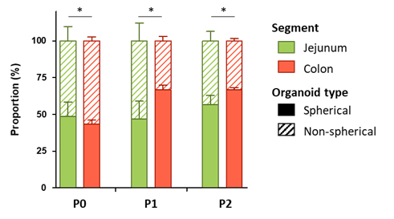

**Stratégie**

- Superposition de 2 barres dont une avec une transparence de 0.4

(https://stackoverflow.com/questions/12715635/ggplot2-bar-plot-with-both-stack-and-dodge)

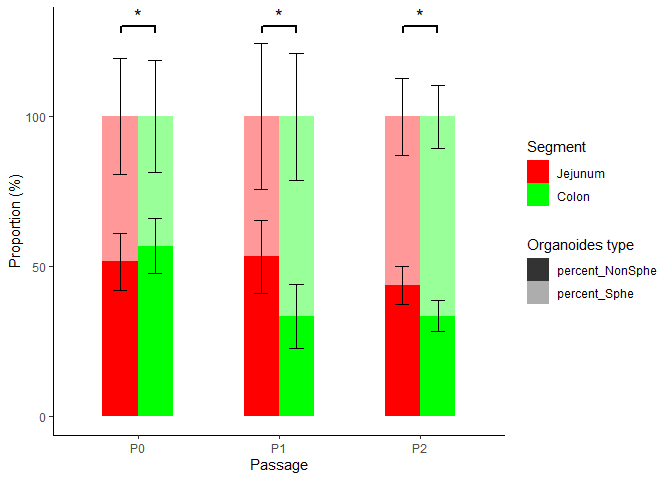

```r
data_stat |>
  group_by(Passage, Segment) |>
  mutate(cum = cumsum(value_moy),
         cum_sd = cumsum(value_sd)) |>
  ggplot(aes(Passage, cum, fill = Segment)) +
  geom_col(data = . %>% filter(Organoids_type == "percent_NonSphe"),
           width = 0.5,
           position = position_dodge(width = 0.5),
           alpha = 1) +
  geom_col(data = . %>% filter(Organoids_type == "percent_Sphe"),
           width = 0.5,
           position = position_dodge(width = 0.5),
           alpha = 0.4) +
  ## légende de la transparence
  geom_tile(aes(y = NA_integer_,
                alpha = Organoids_type)) +
  scale_alpha_manual(values = c(1, 0.4)) +
  scale_fill_manual(values = c("red", "green")) +
  ## barres d'erreur
  geom_errorbar(aes(ymin = cum - cum_sd,
                      ymax = cum + cum_sd),
                  width = .2,
                  position = position_dodge(.5)) +
  ## barres de significativité
  geom_signif(annotation = c("*", "*", "*"),
              y_position = c(130, 130, 130), xmin = c(.88, 1.88, 2.88), xmax = c(1.12, 2.12, 3.12),
              tip_length = 0.02,
              size = 1,
              textsize = 5) +
  labs(y = "Proportion (%)") +
  theme_classic() -> p
## Titre de 2me légende
p$labels$alpha <- "Organoides type"
p
```

Pas réussi à faire mieux, des idées ?